# People Analytics Toy Model - Predicting Attrition with Machine Learning Tools

Katrin Gemmler

Dec 3rd, 2018

# Introduction

The following analysis is based on a fictional human resource database (Source: IBM Analytics). In particular the dataset includes information about the employee attrition among various other features for employees of the given fictional company. Goal of the following analysis is to predict employees who are leaving the company and identify the main drivers for their leaving. The analysis leverages several machine learning tools such as logistic regression, 10-fold crossvalidation and tree-based analysis methods including random forest.

# Chapter 1: Load Libraries and Global Settings

Load all the additional libraries required, load file containing custom functions and set initial global settings:

```r
Loadlibraries = function() {
  library(tidyverse)    # for extension from R base, e.g. ggplot
  library(corrplot)     # for correlation plot
  library(ROCR)         # for ROC curve
  library(pROC)         # for AUC
  library(rpart)        # for tree based classification with rpart
  library(rpart.plot)   # for tree plots with rpart
  library(randomForest) # for randomforest
}
Loadlibraries()
# Loading all custom functions
source("src/utils.R")
source("src/kfoldvalidation.R")
# Set seed for random number generator allowing random objects to be reproduced
set.seed(1234)
```

# Chapter 2: Load, Clean and Explore Data

## Load data and check for missing values

Load data from file.csv and make sure to capture missing values:

```r
# Store data in variable tbl (table) and capture data missing values by replacing "" with NA
tbl <- read.csv("data/EmployeeAttrition.csv", header=TRUE, na.strings=c(""))
```

Check the data for missing values:

```r
# Count missing values
na_count <- rowSums(data.frame(t(colSums(is.na(tbl)))))
#  Report result
cat("There are ", na_count, " missing values in the dataset.")
```

```
There are  0  missing values in the dataset.
```

No pre-cleaning due to missing values is required in this dataset.

## Derive a first understanding of the data

The header names of the data are:

```r
cat(names(tbl), sep=", ")
```

```
Age, Attrition, BusinessTravel, DailyRate, Department, DistanceFromHome, Education, EducationField, EmployeeCount, EmployeeNumber, EnvironmentSatisfaction, Gender, HourlyRate, JobInvolvement, JobLevel, JobRole, JobSatisfaction, MaritalStatus, MonthlyIncome, MonthlyRate, NumCompaniesWorked, Over18, O…
```

The dimension of the data set (rows, columns) is:

```r
cat(dim(tbl), sep = ", ")
```

```
1470, 35
```

This is how the head of the data looks like:

```r
print(head(tbl))
```

|  | Age | Attrition | BusinessTravel | DailyRate | Department | DistanceFromHome | Education | EducationField | EmployeeCount | EmployeeNumber | EnvironmentSatisfaction | Gender | HourlyRate | JobInvolvement | JobLevel | JobRole | JobSatisfaction | MaritalStatus | MonthlyIncome | MonthlyRate | NumCompaniesWorked | Over18 | OverTime | PercentSalaryHike | PerformanceRating | RelationshipSatisfaction | StandardHours | StockOptionLevel | TotalWorkingYears | … |
| --- | --- | --- | --- | --- | --- | --- | --- | --- | --- | --- | --- | --- | --- | --- | --- | --- | --- | --- | --- | --- | --- | --- | --- | --- | --- | --- | --- | --- | --- | --- |
| 1 | 41 | Yes | Travel_Rarely | 1102 | Sales | 1 | 2 | Life Sciences | 1 | 1 | 2 | Female | 94 | 3 | 2 | Sales Executive | 4 | Single | 5993 | 19479 | 8 | Y | Yes | 11 | 3 | 1 | 80 | 0 | 8 | … |
| 2 | 49 | No | Travel_Frequently | 279 | Research & Development | 8 | 1 | Life Sciences | 1 | 2 | 3 | Male | 61 | 2 | 2 | Research Scientist | 2 | Married | 5130 | 24907 | 1 | Y | No | 23 | 4 | 4 | 80 | 1 | 10 | … |
| 3 | 37 | Yes | Travel_Rarely | 1373 | Research & Development | 2 | 2 | Other | 1 | 4 | 4 | Male | 92 | 2 | 1 | Laboratory Technician | 3 | Single | 2090 | 2396 | 6 | Y | Yes | 15 | 3 | 2 | 80 | 0 | 7 | … |
| 4 | 33 | No | Travel_Frequently | 1392 | Research & Development | 3 | 4 | Life Sciences | 1 | 5 | 4 | Female | 56 | 3 | 1 | Research Scientist | 3 | Married | 2909 | 23159 | 1 | Y | Yes | 11 | 3 | 3 | 80 | 0 | 8 | … |
| 5 | 27 | No | Travel_Rarely | 591 | Research & Development | 2 | 1 | Medical | 1 | 7 | 1 | Male | 40 | 3 | 1 | Laboratory Technician | 2 | Married | 3468 | 16632 | 9 | Y | No | 12 | 3 | 4 | 80 | 1 | 6 | … |
| 6 | 32 | No | Travel_Frequently | 1005 | Research & Development | 2 | 2 | Life Sciences | 1 | 8 | 4 | Male | 79 | 3 | 1 | Laboratory Technician | 4 | Single | 3068 | 11864 | 0 | Y | No | 13 | 3 | 3 | 80 | 0 | 8 | … |

R’s summary for the data reads:

```r
summary(tbl)
```

```
      Age        Attrition            BusinessTravel   DailyRate                       Department
 Min.   :18.00   No :1233   Non-Travel       : 150   Min.   : 102.0   Human Resources       : 63
 1st Qu.:30.00   Yes: 237   Travel_Frequently: 277   1st Qu.: 465.0   Research & Development:961
 Median :36.00              Travel_Rarely    :1043   Median : 802.0   Sales                 :446
 Mean   :36.92                                       Mean   : 802.5
 3rd Qu.:43.00                                       3rd Qu.:1157.0
 Max.   :60.00                                       Max.   :1499.0

 DistanceFromHome   Education              EducationField EmployeeCount EmployeeNumber
 Min.   : 1.000   Min.   :1.000   Human Resources : 27    Min.   :1     Min.   :   1.0
 1st Qu.: 2.000   1st Qu.:2.000   Life Sciences   :606    1st Qu.:1     1st Qu.: 491.2
 Median : 7.000   Median :3.000   Marketing       :159    Median :1     Median :1020.5
 Mean   : 9.193   Mean   :2.913   Medical         :464    Mean   :1     Mean   :1024.9
 3rd Qu.:14.000   3rd Qu.:4.000   Other           : 82    3rd Qu.:1     3rd Qu.:1555.8
 Max.   :29.000   Max.   :5.000   Technical Degree:132    Max.   :1     Max.   :2068.0

 EnvironmentSatisfaction    Gender      HourlyRate     JobInvolvement    JobLevel
 Min.   :1.000           Female:588   Min.   : 30.00   Min.   :1.00   Min.   :1.000
 1st Qu.:2.000           Male  :882   1st Qu.: 48.00   1st Qu.:2.00   1st Qu.:1.000
 Median :3.000                        Median : 66.00   Median :3.00   Median :2.000
 Mean   :2.722                        Mean   : 65.89   Mean   :2.73   Mean   :2.064
 3rd Qu.:4.000                        3rd Qu.: 83.75   3rd Qu.:3.00   3rd Qu.:3.000
 Max.   :4.000                        Max.   :100.00   Max.   :4.00   Max.   :5.000

                      JobRole    JobSatisfaction  MaritalStatus MonthlyIncome    MonthlyRate
 Sales Executive          :326   Min.   :1.000   Divorced:327   Min.   : 1009   Min.   : 2094
 Research Scientist       :292   1st Qu.:2.000   Married :673   1st Qu.: 2911   1st Qu.: 8047
 Laboratory Technician    :259   Median :3.000   Single  :470   Median : 4919   Median :14236
 Manufacturing Director   :145   Mean   :2.729                  Mean   : 6503   Mean   :14313
 Healthcare Representative:131   3rd Qu.:4.000                  3rd Qu.: 8379   3rd Qu.:20462
 Manager                  :102   Max.   :4.000                  Max.   :19999   Max.   :26999
 (Other)                  :215
 NumCompaniesWorked Over18   OverTime   PercentSalaryHike PerformanceRating RelationshipSatisfaction
 Min.   :0.000      Y:1470   No :1054   Min.   :11.00     Min.   :3.000     Min.   :1.000
 1st Qu.:1.000               Yes: 416   1st Qu.:12.00     1st Qu.:3.000     1st Qu.:2.000
 Median :2.000                          Median :14.00     Median :3.000     Median :3.000
 Mean   :2.693                          Mean   :15.21     Mean   :3.154     Mean   :2.712
 3rd Qu.:4.000                          3rd Qu.:18.00     3rd Qu.:3.000     3rd Qu.:4.000
 Max.   :9.000                          Max.   :25.00     Max.   :4.000     Max.   :4.000

 StandardHours StockOptionLevel TotalWorkingYears TrainingTimesLastYear WorkLifeBalance YearsAtCompany
 Min.   :80    Min.   :0.0000   Min.   : 0.00     Min.   :0.000         Min.   :1.000   Min.   : 0.000
 1st Qu.:80    1st Qu.:0.0000   1st Qu.: 6.00     1st Qu.:2.000         1st Qu.:2.000   1st Qu.: 3.000
 Median :80    Median :1.0000   Median :10.00     Median :3.000         Median :3.000   Median : 5.000
 Mean   :80    Mean   :0.7939   Mean   :11.28     Mean   :2.799         Mean   :2.761   Mean   : 7.008
 3rd Qu.:80    3rd Qu.:1.0000   3rd Qu.:15.00     3rd Qu.:3.000         3rd Qu.:3.000   3rd Qu.: 9.000
 Max.   :80    Max.   :3.0000   Max.   :40.00     Max.   :6.000         Max.   :4.000   Max.   :40.000

 YearsInCurrentRole YearsSinceLastPromotion YearsWithCurrManager
 Min.   : 0.000     Min.   : 0.000          Min.   : 0.000
 1st Qu.: 2.000     1st Qu.: 0.000          1st Qu.: 2.000
 Median : 3.000     Median : 1.000          Median : 3.000
 Mean   : 4.229     Mean   : 2.188          Mean   : 4.123
 3rd Qu.: 7.000     3rd Qu.: 3.000          3rd Qu.: 7.000
 Max.   :18.000     Max.   :15.000          Max.   :17.000
```

## Data cleaning

The features Over18 and StandardHours have all entries which contain the same values. Thus they do not add any information to the data, which will allow to distinguish employees. To this end Over18 and StandardHours are removed from dataset. EmployeeNumber might be interesting in order to trace back the predictions to a particular employee. But for the purposes of statistical analysis EmployeeNumber and EmployeeCount are also removed:

```r
tbl <- subset(tbl, select = c(-Over18,-StandardHours,-EmployeeCount,-EmployeeNumber))
```

# Chapter 3: Understand Data Correlations

## Correlation heatmap of features

First we look at standard correlation coefficients associated with a linear relationship of features.

Preprocessing data for correlation plots:

```r
# Make sure all values have numerical (necessary for corrplot()). Convert categorical entries into numerical ones first.
tbl.numpart1 <- select_if(tbl, is.numeric)
tbl.fac <- select_if(tbl, is.factor)
tbl.numpart2 <- as.data.frame(sapply(tbl.fac, as.numeric))
tbl.numfull <- cbind(tbl.numpart2,tbl.numpart1)
```

Brief cross-check if data was reattached correctly by looking at dimensions of dataframes before and after modification:

```r
# Compare if old and new dimensions are matching
cat("The dimensions of the modified and original dataset: \n [",dim(tbl.numfull),"]","[",dim(tbl),"]")
```

```
The dimensions of the modified and original dataset:
 [ 1470 31 ] [ 1470 31 ]
```

Visualize standard correlation between all features:

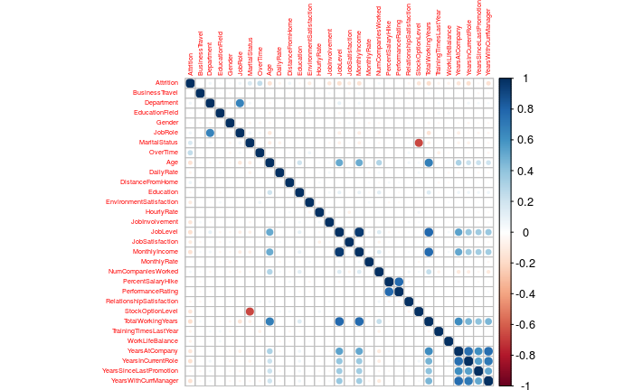

```r
corrplot(cor(tbl.numfull), tl.cex = 0.45)
```

Select correlation for Attrition for a closer look:

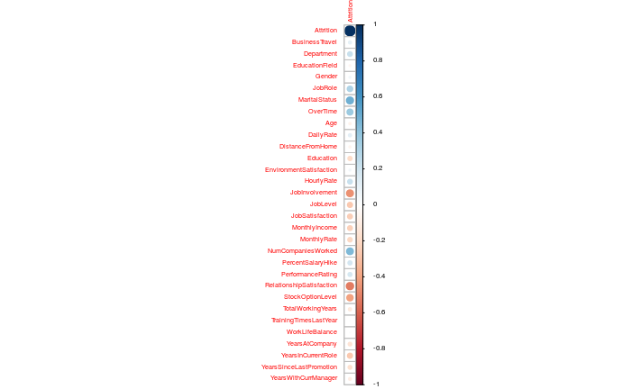

```r
corrplot(
  cor(tbl.numfull[1:length(tbl.numfull),])
  [1:length(tbl.numfull),1, drop=FALSE],
  cl.pos='r',
  cl.align.text = 'l',
  cl.cex = 0.5,
  cl.ratio = 2,
  tl.cex = 0.45
)
```

It should be stressed again that the strength of the correlation in some cases might be missleading since only linear correlation is displayed. Thus we move next to some exploratory analysis in order to understand the dataset in more detail.

## Exploratory analysis to extract further correlations

In this section data correlations are visulatized to show relations between selected features.

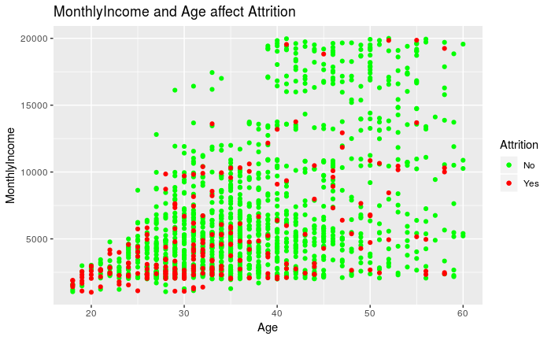

```r
plot1 <- ggplot() +
  geom_point(data = filter(tbl, Attrition == "No"),
             mapping = aes(x = Age, y = MonthlyIncome, color = "green")) +
  geom_point(data = filter(tbl, Attrition == "Yes"),
             mapping = aes(x = Age, y = MonthlyIncome, color = "red")) +
  scale_colour_manual(values = c("green","red")) +
  xlab("Age") + ylab("MonthlyIncome") +
  ggtitle("MonthlyIncome and Age affect Attrition") +
  scale_colour_manual(name = 'Attrition',
                      values = c('green'='green','red'='red'),
                      labels = c('No','Yes'))
plot1
```

It is easy to read that employees with low Age and low MonthlyIncome are more prone to Attrition.

### Plot 2: Does OverTime affect Attrition?

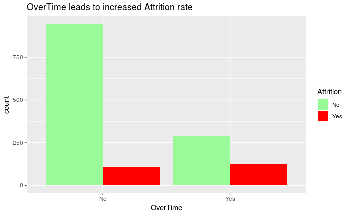

```r
plot2 <- ggplot(data = tbl,aes(x = OverTime, ..count..)) +
  geom_bar(aes(fill = Attrition), position = "dodge") +
  scale_fill_manual(values = c("palegreen","red")) +
  ggtitle("OverTime leads to increased Attrition rate")
plot2
```

Clearly employees with OverTime are more likely to leave the company.

### Plot 3: Does JobSatisfaction prevent Attrition?

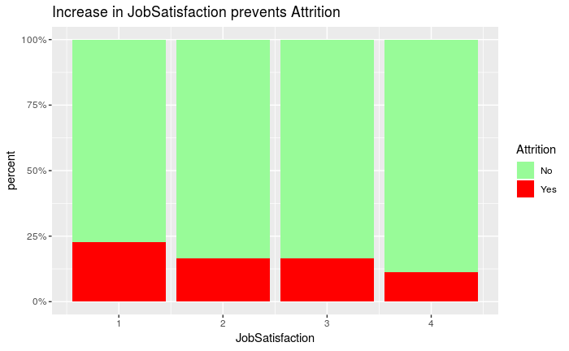

```r
plot3 <- ggplot() +
  geom_bar(data = tbl, aes(x = JobSatisfaction, y = ..count.., fill = Attrition), position = "fill") +
  scale_y_continuous(labels = scales::percent) +
  ylab("percent") +
  scale_fill_manual(values = c("palegreen","red")) +
  ggtitle("Increase in JobSatisfaction prevents Attrition")
plot3
```

JobSatisfaction also does seem to play a role. Increasing the JobSatisfaction of employees seems to lead to a lower rate of Attrition.

### Plot 4: Does WorkLifeBalance prevent Attrition?

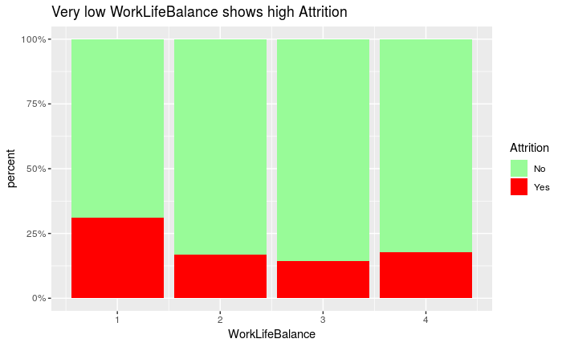

```r
plot4 <- ggplot() +
  geom_bar(data=tbl, aes(x = WorkLifeBalance, y = ..count.., fill = Attrition), position = "fill") +
  scale_y_continuous(labels = scales::percent) +
  scale_fill_manual(values = c("palegreen","red")) +
  ylab("percent") +
  ggtitle("Very low WorkLifeBalance shows high Attrition")
plot4
```

WorkLifeBalance seems to affect Attrition only for very low rates. There is a less pronounced correlation for this feature.

# Chapter 4: Divide into Training and Test Data

In order to carry out further analysis the data needs to be devided into training data and test data. The training data is used to train the statistical models, the test data is used to calculate predictions making use of the pre-trained models. The predictions obtained are then compared to the response which is also part of the test dataset.

```r
# Split data into with 80% of data for training and 20% data for testing
sample <- sample(c(TRUE, FALSE), nrow(tbl), replace = T, prob = c(0.8,0.2))
train <- tbl[sample, ]
test <- tbl[!sample, ]
```

This devision into to dataset is useful to avoid overfitting of model parameters on one particular dataset. Goal is certainly to keep both errors minimal in both training and test data. However it that parameter tuning when involving the test set can also introduce an additional bias.

# Chapter 5: Warmup: Build Simple Logistic Regression Model

We choose a simple logistic regression model to be the first statistical model in order to predict Attrition. This choice is motivated by the fact that we are looking at a classification problem with a binary response (Attrition: Yes/No).

## Model A: Simple Logistic Regression Model

The model predictors (OverTime, MonthlyIncome, JobSatisfaction and Age) are motivated by the exploratory analysis shown above. Response of the model is Attrition, which we aim to predict with this model later on.

```r
# Model A
glm.fit_A <- glm(Attrition ~ OverTime + MonthlyIncome + JobSatisfaction + Age,
                 data = train, family = binomial)
summary(glm.fit_A)
```

```
Call:
glm(formula = Attrition ~ OverTime + MonthlyIncome + JobSatisfaction +
    Age, family = binomial, data = train)

Deviance Residuals:
    Min       1Q   Median       3Q      Max
-1.4606  -0.5936  -0.4456  -0.3001   2.9318

Coefficients:
                  Estimate Std. Error z value Pr(>|z|)
(Intercept)      4.613e-01  4.027e-01   1.146 0.251914
OverTimeYes      1.500e+00  1.693e-01   8.858  < 2e-16 ***
MonthlyIncome   -7.479e-05  2.591e-05  -2.887 0.003895 **
JobSatisfaction -2.911e-01  7.369e-02  -3.950 7.82e-05 ***
Age             -4.033e-02  1.112e-02  -3.628 0.000286 ***
---
Signif. codes:  0 ‘***’ 0.001 ‘**’ 0.01 ‘*’ 0.05 ‘.’ 0.1 ‘ ’ 1

(Dispersion parameter for binomial family taken to be 1)

    Null deviance: 1065.40  on 1173  degrees of freedom
Residual deviance:  933.21  on 1169  degrees of freedom
AIC: 943.21

Number of Fisher Scoring iterations: 5
```

All parameters in Model A are highly statstically significant, indicated by p-value Pr(>|z|) and the stars on the side (see sigificance code above for explanation).

## A bit of statistical background

R chooses Z-statistics as test statistics which assumes a normal distribution with unknown mean and known standard deviation. The null hypothesis corresponds to the data not being dependent on the features X=(OverTime, MonthlyIncome, JobSatisfaction, Age), since the corresponding slope parameter is zero for null hypothesis. The null hypothesis is rejected for p-value < 0.05. In case of rejection the dependence on X is significant for the model.

## Predict Attrition with Model A

Next the test data is used to predict Attrition. The relevant features from test data set need to be extracted first:

```r
dfrmtest_A <- test[, c("OverTime", "MonthlyIncome", "JobSatisfaction", "Age")]
```

Then the prediction for Attrition is calculated with the test dataset using Model A:

```r
result_A <- predict(glm.fit_A, newdata = dfrmtest_A, type = "response")
```

Predicted values for Attrition (see second row values) are given in terms of probablities:

```r
head(result_A)
```

```
         5         14         16         26         28         29
0.18709186 0.09337645 0.14860012 0.01839277 0.08907318 0.03755112
```

Depending on the threshold probabililty prop to be choosen (e.g. in standard setting prop= 0.5) a value > prop indicates a YES and a value < prop indicates a NO.

Comparing these predictions to the actual Attrition of the test data set one can see that the first values are predicted correctly:

```r
head(test$Attrition)
```

```
[1] No No No No No No
Levels: No Yes
```

For a quick assessment of the model performance, we can compute the area under the curve (AUC):

```r
auc(test$Attrition, result_A)
```

```
Area under the curve: 0.7757
```

The AUC originates from the ROC curve, which scans over different shresholds assessing the false positive rate and true positive rate of the prediction. Thus the AUC is threshold independent. When AUC is > 0.5 it indicates that there is a separation capability present in the model. The model is excellent when AUC is close to 1.

# Chapter 6: Refine by Using Extended Logistic Regression Model

The next goal is to improve the separation capability of the simple logistic regression model (Model A) by introducing more features.

## Model B: A comprehensive model to identify significant model parameters

Model B contains considers features present in the dataset.

```r
glm.fit_B <- glm(Attrition ~ ., data = train, family = binomial)
```

The idea is to identify all model parameters which are highly statistical significant:

```r
# Extract model parameters with Pr(>|z|)`<0.01
temp <- as.data.frame(summary(glm.fit_B)$coefficients)
significantParams <- temp[temp$`Pr(>|z|)`<0.01,]
significantParams
```

|  | Estimate | Std. Error | z value | Pr(>\|z\|) |
| --- | --- | --- | --- | --- |
| Age | -0.04124899 | 0.01543946 | -2.671660 | 7.547711e-03 |
| BusinessTravelTravel_Frequently | 1.56392562 | 0.44403429 | 3.522083 | 4.281701e-04 |
| DistanceFromHome | 0.04013498 | 0.01208048 | 3.322300 | 8.927868e-04 |
| EnvironmentSatisfaction | -0.47646395 | 0.09265432 | -5.142382 | 2.712763e-07 |
| JobInvolvement | -0.58118469 | 0.13358106 | -4.350801 | 1.356408e-05 |
| JobRoleLaboratory Technician | 1.47170425 | 0.53350442 | 2.758561 | 5.805654e-03 |
| JobSatisfaction | -0.39092450 | 0.08918371 | -4.383362 | 1.168616e-05 |
| MaritalStatusSingle | 1.02765923 | 0.38525549 | 2.667475 | 7.642367e-03 |
| NumCompaniesWorked | 0.19602109 | 0.04387161 | 4.468063 | 7.893121e-06 |
| OverTimeYes | 1.96582466 | 0.21338511 | 9.212567 | 3.184172e-20 |

[output cut: 4 more lines]

In the next step these significant model parameters are chosen for a refined logistic regression model (Version C). Note that MonthlyIncome is chosen as an additional feature for the refined model since it is one of the few features containing a continuous variable.

## Model C: Refined logistic regression model using statistically significant model parameters

The refined model then reads:

```r
glm.fit_C <- glm(Attrition ~ Age +
                   BusinessTravel +
                   DistanceFromHome +
                   EnvironmentSatisfaction +
                   JobInvolvement +
                   JobSatisfaction +
                   MaritalStatus +
                   MonthlyIncome +
                   NumCompaniesWorked +
                   OverTime +
                   WorkLifeBalance +
                   YearsAtCompany +
                   YearsInCurrentRole +
                   YearsSinceLastPromotion +
                   YearsWithCurrManager,
                 data = train,
                 family = binomial)
```

The output proofs that coefficients of features are statistically significant:

```r
print(summary(glm.fit_C))
```

```
Call:
glm(formula = Attrition ~ Age + BusinessTravel + DistanceFromHome +
    EnvironmentSatisfaction + JobInvolvement + JobSatisfaction +
    MaritalStatus + MonthlyIncome + NumCompaniesWorked + OverTime +
    WorkLifeBalance + YearsAtCompany + YearsInCurrentRole + YearsSinceLastPromotion +
    YearsWithCurrManager, family = binomial, data = train)

Deviance Residuals:
    Min       1Q   Median       3Q      Max
-1.9769  -0.5438  -0.3049  -0.1464   3.2163

Coefficients:
                                  Estimate Std. Error z value Pr(>|z|)
(Intercept)                      2.4136490  0.8075242   2.989 0.002799 **
Age                             -0.0526365  0.0128881  -4.084 4.42e-05 ***
BusinessTravelTravel_Frequently  1.4932222  0.4219395   3.539 0.000402 ***
BusinessTravelTravel_Rarely      0.8725090  0.3920402   2.226 0.026044 *
DistanceFromHome                 0.0318779  0.0111410   2.861 0.004219 **
EnvironmentSatisfaction         -0.4265785  0.0854616  -4.991 5.99e-07 ***
JobInvolvement                  -0.6316549  0.1267489  -4.984 6.24e-07 ***
JobSatisfaction                 -0.3592552  0.0831657  -4.320 1.56e-05 ***
MaritalStatusMarried             0.4998563  0.2759794   1.811 0.070109 .
MaritalStatusSingle              1.3725718  0.2742862   5.004 5.61e-07 ***
MonthlyIncome                   -0.0001113  0.0000329  -3.385 0.000713 ***
NumCompaniesWorked               0.1662261  0.0390652   4.255 2.09e-05 ***
OverTimeYes                      1.7271826  0.1927240   8.962  < 2e-16 ***
WorkLifeBalance                 -0.2725930  0.1307783  -2.084 0.037125 *
YearsAtCompany                   0.0801561  0.0354953   2.258 0.023932 *
YearsInCurrentRole              -0.1309824  0.0454492  -2.882 0.003952 **
YearsSinceLastPromotion          0.1407535  0.0426351   3.301 0.000962 ***
YearsWithCurrManager            -0.1421469  0.0471560  -3.014 0.002575 **
---
Signif. codes:  0 ‘***’ 0.001 ‘**’ 0.01 ‘*’ 0.05 ‘.’ 0.1 ‘ ’ 1

(Dispersion parameter for binomial family taken to be 1)

    Null deviance: 1065.40  on 1173  degrees of freedom
Residual deviance:  773.74  on 1156  degrees of freedom
AIC: 809.74

Number of Fisher Scoring iterations: 6
```

## Assess Predictive Performance of Model C

As explained above threshold independent model performance can be assessed via calulating the AUC:

```r
# Extract relevant data from test data set in order to calculate prediction
dfrmtest_C <- test[, c("Age",
                       "BusinessTravel",
                       "DistanceFromHome",
                       "EnvironmentSatisfaction",
                       "JobInvolvement",
                       "JobSatisfaction",
                       "MaritalStatus",
                       "MonthlyIncome",
                       "NumCompaniesWorked",
                       "OverTime",
                       "WorkLifeBalance",
                       "YearsAtCompany",
                       "YearsInCurrentRole",
                       "YearsSinceLastPromotion",
                       "YearsWithCurrManager")]
# Calculate predictions using test data extract
result_C <- predict(glm.fit_C, newdata=dfrmtest_C, type="response")
# Derive area under the ROC curve (AUC), syntax (response, predictor)
auc(test$Attrition, result_C)
```

```
Area under the curve: 0.8278
```

The value of Model C is higher compared to the value of Model A and thus indicates improved separation capability for the refined version (Model C).

Next we have a closer look at the ROC curve of Model C is given by true positive rate (sensitivity) over false positive rate (1 - specificity):

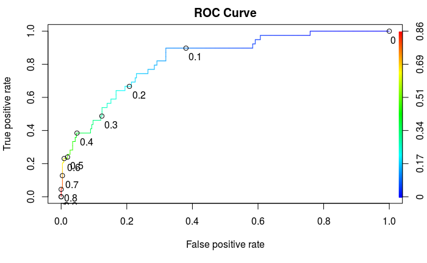

```r
# using function rocplot(pred,truth,...) from file utils.R
rocplot(result_C,
        test$Attrition,
        colorize=TRUE,
        print.cutoffs.at=seq(0,1,by=0.1),
        text.adj=c(-0.2,1.7),
        main="ROC Curve")
```

The ROC curve indicates threshold prop = 0.16 to be a good choice for calculating performance specifics. For this specific threshold confusion matrix, accurarcy, sensitivity and specificity of Model C can be calculated:

```r
# Use function confusionmatrix(testdata, modelpred, threshold) from file utils.R The function returns the confusion matrix, accuracy, sensitivity and specificity as list
conf <- confusionmatrix(test$Attrition, result_C, 0.16)
```

The confusion matrix given by

```r
conf[[1]]
```

```
testdata FALSE TRUE
     No    191   66
     Yes    10   29
```

```r
cat("Model accuracy is:", format(conf[[2]] * 100, digits=3),"%.\n")
```

```
Model accuracy is: 74.3 %.
```

```r
cat("Model sensitivity is:", format(conf[[3]] * 100, digits=3),"%.\n")
```

```
Model sensitivity is: 74.4 %.
```

```r
cat("Model specificity is:", format(conf[[4]] * 100, digits=3),"%.\n")
```

```
Model specificity is: 74.3 %.
```

Note that threshold tuning on the test set can also introduce a bias and has to be applied with care. Overall Model C is capable to identify indiviual employees that are leaving the company.

# Chapter 7: Evaluate Performance Stability with 10-fold Cross-validation

The next step is to evaluate how stable Model C (Refined logistic regression model) performs under different datasets. Since the here data is very limited, such assessment can be performed using k-fold cross-validation. K-fold cross-validation partions data in k-folds and then uses the kth fold as test data set while the remaining folds (excluding the kth fold) are used for training. In total there are k possibilities to assign the test data leading to k different predictive models. This allows to make k predictions and is useful to examine variability of responses. Note that k-fold cross-validation also can be used to reduce variance for the resulting performance estimate by averaging over the k different partitions. For this example 10-fold cross-validation is chosen.

In order to perform 10-fold cross-validation the function kFoldValidation defined in kfoldvalidation.R is used. The function takes the number of folds, data, modelformula and a threshold as inputs, and outputs a list of vectors containing the AUC, accuracy, sensitivity and specificity.

```r
modelfmla <- Attrition ~ Age +
                        BusinessTravel +
                        DistanceFromHome +
                        EnvironmentSatisfaction +
                        JobInvolvement +
                        JobSatisfaction +
                        MaritalStatus +
                        MonthlyIncome +
                        NumCompaniesWorked +
                        OverTime +
                        WorkLifeBalance +
                        YearsAtCompany +
                        YearsInCurrentRole +
                        YearsSinceLastPromotion +
                        YearsWithCurrManager
validationresult <- kFoldValidation(10,tbl,modelfmla,0.16)
vector_auc <- validationresult[[1]]
vector_acc <- validationresult[[2]]
vector_sen <- validationresult[[3]]
vector_spe <- validationresult[[4]]
```

Boxplot shows the variability in AUC:

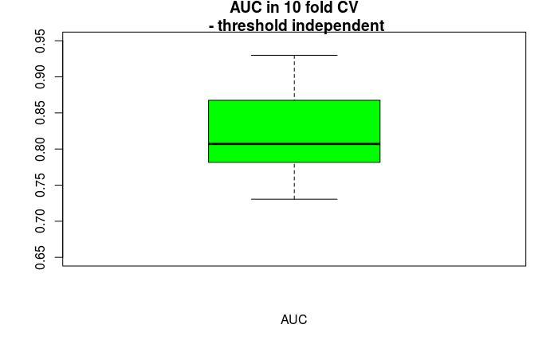

```r
boxplot(vector_auc, col="green", border="black", horizontal=FALSE,
        xlab="AUC",  ylim = c(0.65, 0.95), main="AUC in 10 fold CV\n - threshold independent")
```

The mean for the AUC resulting from 10-fold cross-validation is given by:

```r
cat("Model average AUC is:", mean(vector_auc),"\n")
```

```
Model average AUC is: 0.8203435
```

Similarly variability for accuracy, sensitivity and specificity can be displayed for specific threshold (here: prop = 0.16)

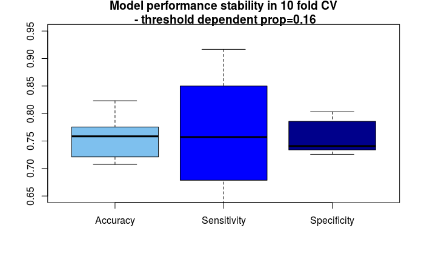

```r
# Reshape results to use for boxplot
res_cv <- c(vector_acc, vector_sen, vector_spe)
category <- c(rep("Accuracy", 10), rep("Sensitivity", 10), rep("Specificity", 10))
category <- factor(category, levels=c("Accuracy", "Sensitivity", "Specificity"))
# Perform boxplot
boxplot(res_cv ~ category, col=c("skyblue2","blue","darkblue"), pch=19, ylim = c(0.65, 0.95),
        main="Model performance stability in 10 fold CV\n - threshold dependent prop=0.16")
```

The corresponding means for threshold prop = 0.16 are given by:

```r
cat("Model average accuracy (with threshold propobabiltiy = 0.16) is:", mean(vector_acc),"\n")
```

```
Model average accuracy (with threshold propobabiltiy = 0.16) is: 0.7571429
```

```r
cat("Model average sensitivity (with threshold propobabiltiy = 0.16) is:", mean(vector_sen),"\n")
```

```
Model average sensitivity (with threshold propobabiltiy = 0.16) is: 0.7582356
```

```r
cat("Model average specificity (with threshold propobabiltiy = 0.16) is:", mean(vector_spe),"\n")
```

```
Model average specificity (with threshold propobabiltiy = 0.16) is: 0.7560568
```

# Chapter 8: Use Tree-based methods

In this chapter makes use of decision trees to solve the classification problem stated above. The goal of a classifcation tree is to split up data for the features assessed, at each step that best splits are chosen maximizing purity in each node.

Generally decision trees have some advantages over logistic regression: First, trees allow to graphically interpret model drivers. Second, if model features are chose to be not hand-selected, trees can perform implicit feature selection. The trade-off is that tree-algorithms are generally “greedy”. This means the best data split is assessed at the particular given step only. The algorithm does not look ahead and choose a data split which would lead to a better classification result in a future step of the tree-building process. Additionally a disadvantage is that considering a single tree is often less robust to changes in the dataset.

## Model D: A basic tree-based model with hand-selected features

For this basic hand-selected tree model (Model D), we select the same features chosen in the simple regression (Model A). Note that choosing instead the features of Model C, would not lead to an improved performance. Thus we restrict to the most simple version here:

```r
rpart.fit_D <- rpart(Attrition ~ OverTime + MonthlyIncome + JobSatisfaction + Age,  data = train, method="class")
# Note: Instead of rpart() is it also possible to use tree() from the library(tree).
rpart.fit_D
```

```
n= 1174

node), split, n, loss, yval, (yprob)
      * denotes terminal node

 1) root 1174 198 No (0.8313458 0.1686542)
   2) OverTime=No 842  91 No (0.8919240 0.1080760) *
   3) OverTime=Yes 332 107 No (0.6777108 0.3222892)
     6) MonthlyIncome>=2475 274  66 No (0.7591241 0.2408759) *
     7) MonthlyIncome< 2475 58  17 Yes (0.2931034 0.7068966)
      14) Age>=37.5 11   4 No (0.6363636 0.3636364) *
      15) Age< 37.5 47  10 Yes (0.2127660 0.7872340) *
```

More information can be obtained using R’s summary:

```r
summary(rpart.fit_D)
```

```
Call:
rpart(formula = Attrition ~ OverTime + MonthlyIncome + JobSatisfaction +
    Age, data = train, method = "class")
  n= 1174

          CP nsplit rel error    xerror       xstd
1 0.06060606      0 1.0000000 1.0000000 0.06479750
2 0.01515152      2 0.8787879 0.9090909 0.06234910
3 0.01000000      3 0.8636364 0.9343434 0.06304995

Variable importance
     OverTime MonthlyIncome           Age
           45            43            12

Node number 1: 1174 observations,    complexity param=0.06060606
  predicted class=No   expected loss=0.1686542  P(node) =1
    class counts:   976   198
   probabilities: 0.831 0.169
  left son=2 (842 obs) right son=3 (332 obs)
  Primary splits:
      OverTime        splits as  LR,         improve=21.852660, (0 missing)
      MonthlyIncome   < 2973.5 to the right, improve=13.538960, (0 missing)
      Age             < 31.5   to the right, improve=11.041600, (0 missing)
      JobSatisfaction < 1.5    to the right, improve= 3.664684, (0 missing)

Node number 2: 842 observations
  predicted class=No   expected loss=0.108076  P(node) =0.7172061
    class counts:   751    91
   probabilities: 0.892 0.108

Node number 3: 332 observations,    complexity param=0.06060606
  predicted class=No   expected loss=0.3222892  P(node) =0.2827939
    class counts:   225   107
   probabilities: 0.678 0.322
  left son=6 (274 obs) right son=7 (58 obs)
  Primary splits:
      MonthlyIncome   < 2475   to the right, improve=20.79126, (0 missing)
      Age             < 33.5   to the right, improve=12.75075, (0 missing)
      JobSatisfaction < 3.5    to the right, improve= 2.80753, (0 missing)
  Surrogate splits:
```

[output cut: 11 more lines]

```
  left son=14 (11 obs) right son=15 (47 obs)
  Primary splits:
      Age             < 37.5   to the right, improve=3.198893, (0 missing)
      MonthlyIncome   < 2124   to the right, improve=1.480681, (0 missing)
      JobSatisfaction < 2.5    to the right, improve=1.077340, (0 missing)

Node number 14: 11 observations
  predicted class=No   expected loss=0.3636364  P(node) =0.009369676
    class counts:     7     4
   probabilities: 0.636 0.364

Node number 15: 47 observations
  predicted class=Yes  expected loss=0.212766  P(node) =0.04003407
    class counts:    10    37
   probabilities: 0.213 0.787
```

The the graphical interpretation is the following:

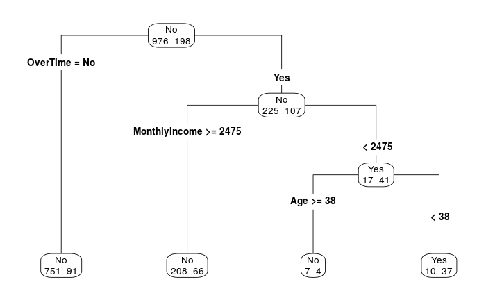

```r
print(prp(rpart.fit_D, fallen.leaves = TRUE, type=4, extra=1, varlen=0, faclen=0, yesno.yshift=-1))
```

The employer obtain the following about its employees:

1. People without OverTime are generally less affected from Attrition.
2. People with OverTime are safer from Attrition if their MonthlyIncome is > 2475 Dollars.
3. People with lower MonthlyIncome (< 2475 dollars) and with Age < 38 belong to the riskgroup for Attrition.

Note that some of these results where already indicated by the initial exploratory analysis e.g. in plot 1 and 2.

Next we derive the prediction for Mdoel D:

```r
# Testdata selection is analogue to model A since same features where chosen
dfrmtest_D <- dfrmtest_A
# Calculate prediction
result_D <- predict(rpart.fit_D, dfrmtest_D)
head(result_D)
```

```
         No      Yes
5  0.891924 0.108076
14 0.891924 0.108076
16 0.891924 0.108076
26 0.891924 0.108076
28 0.891924 0.108076
29 0.891924 0.108076
```

The result contains probabilities for the predicted responses for Attrition.

The AUC of Model D is given by:

```r
auc(test$Attrition, result_D[,'Yes'])
```

```
Area under the curve: 0.6502
```

This is a relative poor results compared to the predictivity we obtained using logistic regression.

The final prediction depends on the threshold chosen (just as above in the logistic regression models). Standard would be a threshold of prop = 0.5. But in order to make analysis more comparable to the previously considered regression model, a similar threshold is chosen here (prop = 0.16). The confusion matrix then reads:

```r
confusionmatrix(test$Attrition, result_D[,'Yes'], 0.16)[[1]]
```

```
testdata FALSE TRUE
     No    193   64
     Yes    19   20
```

## Model E: A comprehensive tree with implicite feature selection

Next we want to make use of implicite feature selection. Thus model features are not pre-assigned by hand. We start with the most general decision tree model for this dataset by including all features. Later we continue by pruning the tree to an optimal size in order to avoid overfitting of the data.

The most general tree classification model reads:

```r
rpart.fit_E <- rpart(Attrition ~., data = train, method ="class")
rpart.fit_E
```

```
n= 1174

node), split, n, loss, yval, (yprob)
      * denotes terminal node

  1) root 1174 198 No (0.83134583 0.16865417)
    2) OverTime=No 842  91 No (0.89192399 0.10807601)
      4) TotalWorkingYears>=1.5 790  73 No (0.90759494 0.09240506) *
      5) TotalWorkingYears< 1.5 52  18 No (0.65384615 0.34615385)
       10) HourlyRate>=58.5 33   6 No (0.81818182 0.18181818) *
       11) HourlyRate< 58.5 19   7 Yes (0.36842105 0.63157895) *
    3) OverTime=Yes 332 107 No (0.67771084 0.32228916)
      6) MonthlyIncome>=2475 274  66 No (0.75912409 0.24087591)
       12) StockOptionLevel>=0.5 158  20 No (0.87341772 0.12658228) *
       13) StockOptionLevel< 0.5 116  46 No (0.60344828 0.39655172)
         26) JobRole=Healthcare Representative,Human Resources,Manager,Manufacturing Director,Research Director,Research Scientist 67  14 No (0.79104478 0.20895522) *
         27) JobRole=Laboratory Technician,Sales Executive,Sales Representative 49  17 Yes (0.34693878 0.65306122)
           54) MonthlyIncome< 8163.5 38  17 Yes (0.44736842 0.55263158)
            108) MonthlyRate< 17091 23   9 No (0.60869565 0.39130435)
              216) DistanceFromHome< 4.5 13   2 No (0.84615385 0.15384615) *
              217) DistanceFromHome>=4.5 10   3 Yes (0.30000000 0.70000000) *
            109) MonthlyRate>=17091 15   3 Yes (0.20000000 0.80000000) *
           55) MonthlyIncome>=8163.5 11   0 Yes (0.00000000 1.00000000) *
      7) MonthlyIncome< 2475 58  17 Yes (0.29310345 0.70689655)
       14) DailyRate>=975.5 23  11 No (0.52173913 0.47826087)
         28) YearsInCurrentRole>=2.5 7   0 No (1.00000000 0.00000000) *
         29) YearsInCurrentRole< 2.5 16   5 Yes (0.31250000 0.68750000) *
       15) DailyRate< 975.5 35   5 Yes (0.14285714 0.85714286) *
```

For better overview it is nice to visualiye the tree for Model E before pruning:

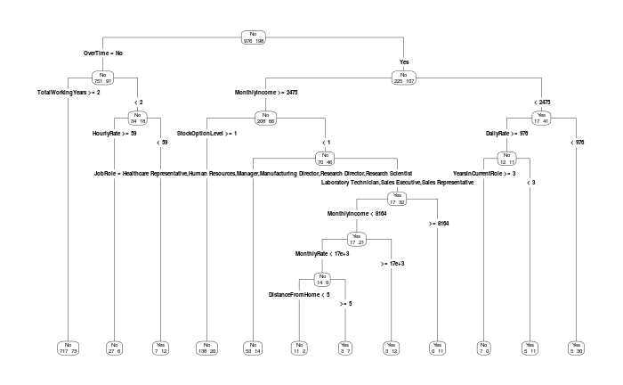

```r
print(prp(rpart.fit_E, fallen.leaves = TRUE, type=4, extra=1, varlen=0, faclen=0, yesno.yshift=-1))
```

The next step is to use the complexity parameter (cp) to control the size of the classification tree. The optimal tree size is achieved when the cost of adding another feature to the decision tree from the current node is above the value of cp. In this case the tree building process is not continued.

The values for the complexity parameter read:

```r
printcp(rpart.fit_E)
```

```
Classification tree:
rpart(formula = Attrition ~ ., data = train, method = "class")

Variables actually used in tree construction:
 [1] DailyRate          DistanceFromHome   HourlyRate         JobRole            MonthlyIncome
 [6] MonthlyRate        OverTime           StockOptionLevel   TotalWorkingYears  YearsInCurrentRole

Root node error: 198/1174 = 0.16865

n= 1174

        CP nsplit rel error  xerror     xstd
1 0.060606      0   1.00000 1.00000 0.064798
2 0.037879      2   0.87879 0.95455 0.063599
3 0.017677      4   0.80303 0.89899 0.062064
4 0.012626      6   0.76768 0.93434 0.063050
5 0.010000     11   0.69697 0.91919 0.062631
```

xerror is the cross-validation error (rpart has already a built-in cross validation).

The xerror can be shown as a function of the complexity parameter:

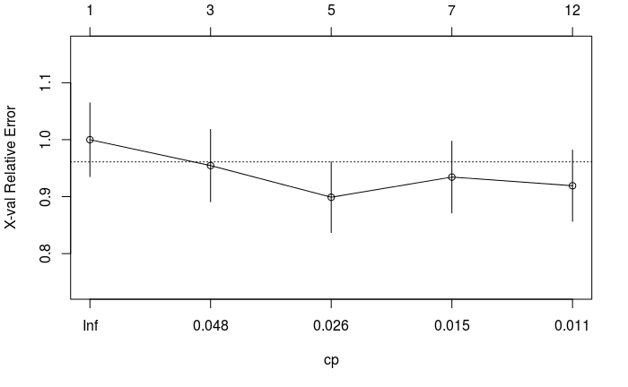

```r
print(plotcp(rpart.fit_E))
```

Generally for pruning one chooses a small tree with the least cross validated error:

```r
prune.rpart.fit_E <- prune(rpart.fit_E, cp= rpart.fit_E$cptable[which.min(rpart.fit_E$cptable[,"xerror"]),"CP"])
```

The pruned tree (Model E) looks then like:

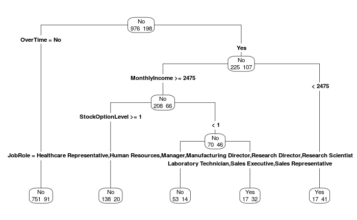

```r
print(prp(prune.rpart.fit_E, fallen.leaves = TRUE, type=4, extra=1, varlen=0, faclen=0, yesno.yshift=-1))
```

OverTime and MonthlyIncome appear automatically as some of the most important decision features. Note that those features we have already chosen in simple tree of Model D.

Use test data to make prediction:

```r
dfrmtest_E <- test
result_E <- predict(rpart.fit_E, dfrmtest_E)
```

The AUC of model E is given by:

```r
auc(test$Attrition, result_E[,'Yes'])
```

```
Area under the curve: 0.7241
```

The model predictivity is improved significantly compared to simple tree (Model D) but cannot reach predictivity of logistic regression.

Confusion matrix for Model E (with threshold chosen to be prop = 0.16) is given by:

```r
confusionmatrix(test$Attrition, result_E[,'Yes'], 0.16)[[1]]
```

```
testdata FALSE TRUE
     No    229   28
     Yes    22   17
```

# Chapter 9: Improve Tree-based Prediction through Random Forest

The predictive performance of decision trees can be improved significantly by aggregating multiple decision trees. Common methods are bagging, random forests, and boosting. The analysis here restricts on random forest. Random forest uses bootstrap aggregation just like bagging, but extends bagging with additional a variable (and random) feature selection. Random forest helps to reduce the variance compared to a single decision tree. Random forest can also handle dataset with high dimensions well.

## Model F: General Random Forest model

The most general random forest model is given by:

```r
rf.fit_F <- randomForest(Attrition ~.,
                        data = train, replace=TRUE, importance=TRUE, do.trace=4, ntree=100)
```

Note that the feature selection (mytry) is set to default (close to squareroot of total number of features), which leads to a good fit in this case.

Visualize reduced out-of-bag error through training on trees:

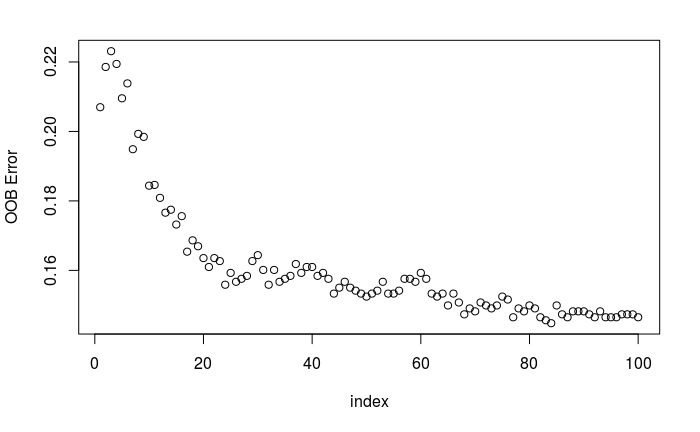

```r
plot(rf.fit_F$err.rate[,'OOB'],  xlab = "index", ylab = "OOB Error")
```

Next we assess the importance of the different features:

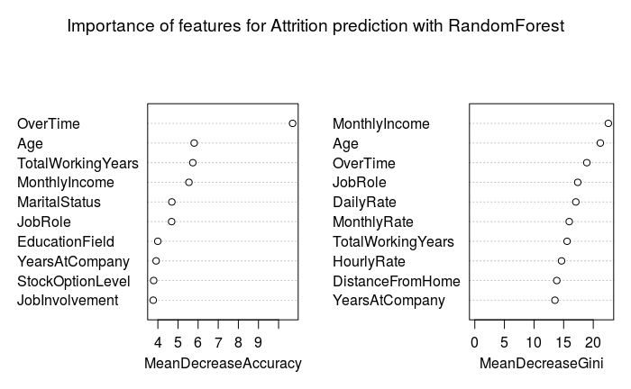

```r
varImpPlot(rf.fit_F, main="Importance of features for Attrition prediction with RandomForest", n.var=10)
```

Next we make the prediction using the test dataset:

```r
result_F <- predict(rf.fit_F, test)
result_prob_F <- predict(rf.fit_F, test, type = "prob")
```

We specify output depending on the desired result:

```r
head(result_F)
```

```
 5 14 16 26 28 29
No No No No No No
Levels: No Yes
```

```r
head(result_prob_F)
```

```
     No  Yes
5  0.78 0.22
14 0.92 0.08
16 0.93 0.07
26 0.98 0.02
28 0.92 0.08
29 0.81 0.19
```

The AUC for the random forest model (Model F) reads:

```r
auc(test$Attrition, result_prob_F[,'Yes'])
```

```
Area under the curve: 0.8285
```

This is a quiet good performance and in the same ballpark the best regression model.

# Summary and Outlook

## Summarizing Results and Recommendations

In this analysis we predicted Attrition for employees of a fictional HR database leveraging Machine Learning Tools.

First we solved this classification problem via logistic regression. By pre-selecting only statistically sigificant coefficients we could come up with a refined logistic regression model (Model C) where the AUC is given by

```r
auc(test$Attrition, result_C)
```

```
Area under the curve: 0.8278
```

The model has predictive capability to identify indiviual employees that are leaving the company. Further we determined via 10-fold crossvalidation that the model is relatively stable for changes on the dataset.

The most important model drivers (significance > 0.001) have been identified as: Age, BusinessTravelTravel, EnvironmentSatisfaction, JobInvolvement, JobSatisfaction, MaritalStatus, MonthlyIncome, NumCompaniesWorked, TimeYes and YearsSinceLastPromotion

Next we assessed the classification problem using tree-based methods. In this case model features can be implicitly selected without preassessing the data. Best results were obtained using random forest (Model F) with predictabilty comparable to the logistic regression model. In particular the AUC reads

```r
auc(test$Attrition, result_prob_F[,'Yes'])
```

```
Area under the curve: 0.8285
```

Top 10 model drivers could be either be selected by highest MeanDecreaseAccuracy or MeanDecreaseGini.

```r
fff <- as.data.frame(rf.fit_F$importance)
cat("Gini Drivers: \n", row.names(fff[order(fff$MeanDecreaseGini, decreasing= T),])[1:10], sep ="\n")
```

```
Gini Drivers:

MonthlyIncome
Age
OverTime
JobRole
DailyRate
MonthlyRate
TotalWorkingYears
HourlyRate
DistanceFromHome
YearsAtCompany
```

```r
cat("\n")
```

```r
cat("Accuracy Drivers: \n", row.names(fff[order(fff$MeanDecreaseAccuracy, decreasing= T),])[1:10], sep ="\n")
```

```
Accuracy Drivers:

OverTime
Age
TotalWorkingYears
JobRole
MonthlyIncome
StockOptionLevel
MaritalStatus
JobLevel
YearsAtCompany
EducationField
```

The employer can use information about risk target groups (see tree plots related to tree-based Model D and E) as well as stated above model drivers to improve retention of highly valued employees.

## Next Steps Towards a Real People Analytics Software

Step 1. Refine machine learning techniques - Optimize parameters of assessed models - Try other machine learning techiques e.g. neural networks Step 2. Improvement of content: - Use a more HR data base with more features and data - Create more predictions e.g. predict employer performance Step 3. Improvement of frontend to make a usable model - Create an interface for clients to upload data - Create an automated output for clients e.g. dashboard output